# Regression - Predicting Possum Head Length

The possum dataset consists of nine morphometric measurements and additional details such as sex and age on each of 104 mountain brushtail possums, trapped at seven sites from Southern Victoria to Central Queensland. The dataset was originally part of the DAAG R package and is available on [Kaggle](https://www.kaggle.com/abrambeyer/openintro-possum).

#### Exploring the Data

```python
import pandas as pd
import numpy as np
import matplotlib.pyplot as plt
import seaborn as sns
from sklearn.preprocessing import OneHotEncoder
from sklearn.model_selection import train_test_split, cross_val_score
```

```python
possum_df = pd.read_csv("datasets/possum.csv")
```

```python
possum_df.sample(5)
```

|  | case | site | Pop | sex | age | hdlngth | skullw | totlngth | taill | footlgth | earconch | eye | chest | belly |
| --- | --- | --- | --- | --- | --- | --- | --- | --- | --- | --- | --- | --- | --- | --- |
| 75 | 76 | 6 | other | m | 5.0 | 92.4 | 56.8 | 89.0 | 41.0 | 64.5 | 46.4 | 17.8 | 26.0 | 33.0 |
| 38 | 39 | 2 | Vic | f | 1.0 | 84.7 | 51.5 | 75.0 | 34.0 | 68.7 | 53.4 | 13.0 | 25.0 | 25.0 |
| 32 | 33 | 1 | Vic | m | 3.0 | 91.4 | 54.6 | 89.0 | 37.0 | 70.8 | 51.8 | 14.8 | 24.0 | 30.0 |
| 30 | 31 | 1 | Vic | m | 3.0 | 92.8 | 54.1 | 93.0 | 37.0 | 68.0 | 52.5 | 14.5 | 27.0 | 31.0 |
| 96 | 97 | 7 | other | m | 3.0 | 91.0 | 53.1 | 86.0 | 38.0 | 63.8 | 46.0 | 14.5 | 25.0 | 31.5 |

```python
# dropping case column
possum_df.drop(["case"], axis=1, inplace=True)
```

```python
possum_df.info()
```

```
<class 'pandas.core.frame.DataFrame'>
RangeIndex: 104 entries, 0 to 103
Data columns (total 13 columns):
 #   Column    Non-Null Count  Dtype
---  ------    --------------  -----
 0   site      104 non-null    int64
 1   Pop       104 non-null    object
 2   sex       104 non-null    object
 3   age       102 non-null    float64
 4   hdlngth   104 non-null    float64
 5   skullw    104 non-null    float64
 6   totlngth  104 non-null    float64
 7   taill     104 non-null    float64
 8   footlgth  103 non-null    float64
 9   earconch  104 non-null    float64
 10  eye       104 non-null    float64
 11  chest     104 non-null    float64
 12  belly     104 non-null    float64
dtypes: float64(10), int64(1), object(2)
memory usage: 10.7+ KB
```

```python
# dropping records with missing values
possum_df.dropna(inplace=True)
```

```python
possum_df.reset_index(drop=True, inplace=True)
```

```python
possum_df["age"] = possum_df["age"].astype("int64")
```

```python
possum_df.sample(5)
```

|  | site | Pop | sex | age | hdlngth | skullw | totlngth | taill | footlgth | earconch | eye | chest | belly |
| --- | --- | --- | --- | --- | --- | --- | --- | --- | --- | --- | --- | --- | --- |
| 96 | 7 | other | m | 1 | 89.5 | 56.0 | 81.5 | 36.5 | 66.0 | 46.8 | 14.8 | 23.0 | 27.0 |
| 31 | 1 | Vic | f | 4 | 94.3 | 56.7 | 94.0 | 39.0 | 74.8 | 52.0 | 14.9 | 28.0 | 34.0 |
| 12 | 1 | Vic | m | 5 | 95.1 | 59.9 | 89.5 | 36.0 | 71.0 | 49.8 | 15.8 | 27.0 | 32.0 |
| 51 | 4 | other | m | 2 | 103.1 | 63.2 | 92.5 | 38.0 | 72.5 | 44.9 | 16.4 | 30.5 | 36.0 |
| 95 | 7 | other | f | 3 | 93.3 | 56.2 | 86.5 | 38.5 | 64.8 | 43.8 | 14.0 | 28.0 | 35.0 |

```python
possum_df.shape
```

```
(101, 13)
```

```python
# list of columns
col_list = possum_df.columns
```

Different Measurements

Head length, skull width, foot length, ear conch length and eye are measured in mm while total length, tail length, chest girth and belly girth are in cm - let's make the measurements uniform and convert to cm where required.

```python
for col in ["hdlngth", "skullw", "footlgth", "earconch", "eye"]:
    possum_df[col] = possum_df[col] / 10
```

```python
possum_df.sample(5)
```

|  | site | Pop | sex | age | hdlngth | skullw | totlngth | taill | footlgth | earconch | eye | chest | belly |
| --- | --- | --- | --- | --- | --- | --- | --- | --- | --- | --- | --- | --- | --- |
| 83 | 7 | other | m | 2 | 9.85 | 6.07 | 93.0 | 41.5 | 7.17 | 4.68 | 1.50 | 26.0 | 36.0 |
| 90 | 7 | other | m | 7 | 9.18 | 5.76 | 84.0 | 35.5 | 6.42 | 4.51 | 1.44 | 29.0 | 35.0 |
| 65 | 5 | other | m | 5 | 9.80 | 5.56 | 88.0 | 37.5 | 6.50 | 4.56 | 1.50 | 28.5 | 34.0 |
| 37 | 2 | Vic | m | 7 | 9.24 | 5.60 | 80.5 | 35.5 | 6.84 | 4.95 | 1.59 | 27.0 | 30.0 |
| 36 | 2 | Vic | f | 2 | 8.93 | 5.48 | 82.5 | 35.0 | 7.12 | 5.20 | 1.36 | 28.0 | 31.5 |

Female vs Male Possums

```python
# mean values
round(possum_df.groupby(by="sex")[col_list[3:]].mean(), 2)
```

| sex | age | hdlngth | skullw | totlngth | taill | footlgth | earconch | eye | chest | belly |
| --- | --- | --- | --- | --- | --- | --- | --- | --- | --- | --- |
| f | 3.95 | 9.22 | 5.66 | 88.02 | 37.12 | 6.91 | 4.88 | 1.48 | 27.35 | 32.94 |
| m | 3.73 | 9.31 | 5.72 | 86.73 | 37.00 | 6.79 | 4.77 | 1.52 | 26.86 | 32.42 |

```python
# min values
round(possum_df.groupby(by="sex")[col_list[3:]].min(), 2)
```

| sex | age | hdlngth | skullw | totlngth | taill | footlgth | earconch | eye | chest | belly |
| --- | --- | --- | --- | --- | --- | --- | --- | --- | --- | --- |
| f | 1 | 8.47 | 5.15 | 75.0 | 32.0 | 6.03 | 4.13 | 1.30 | 23.0 | 25.0 |
| m | 1 | 8.25 | 5.00 | 77.0 | 32.0 | 6.20 | 4.17 | 1.28 | 22.0 | 27.0 |

```python
# max values
round(possum_df.groupby(by="sex")[col_list[3:]].max(), 2)
```

| sex | age | hdlngth | skullw | totlngth | taill | footlgth | earconch | eye | chest | belly |
| --- | --- | --- | --- | --- | --- | --- | --- | --- | --- | --- |
| f | 9 | 9.69 | 6.77 | 96.5 | 41.0 | 7.79 | 5.39 | 1.74 | 31.0 | 40.0 |
| m | 8 | 10.31 | 6.86 | 96.0 | 43.0 | 7.50 | 5.62 | 1.78 | 32.0 | 38.0 |

Different Age Groups

```python
round(possum_df.groupby(by="age")[col_list[4:]].mean(), 2)
```

| age | hdlngth | skullw | totlngth | taill | footlgth | earconch | eye | chest | belly |
| --- | --- | --- | --- | --- | --- | --- | --- | --- | --- |
| 1 | 8.78 | 5.43 | 82.75 | 36.40 | 6.61 | 4.74 | 1.44 | 24.95 | 29.30 |
| 2 | 9.33 | 5.71 | 87.38 | 36.56 | 7.06 | 4.93 | 1.48 | 27.16 | 32.31 |
| 3 | 9.25 | 5.66 | 87.71 | 37.43 | 6.76 | 4.75 | 1.49 | 26.74 | 32.50 |
| 4 | 9.27 | 5.64 | 86.57 | 37.04 | 6.83 | 4.86 | 1.52 | 27.36 | 33.25 |
| 5 | 9.45 | 5.85 | 87.79 | 36.50 | 6.76 | 4.70 | 1.58 | 27.83 | 34.08 |
| 6 | 9.38 | 5.78 | 89.83 | 37.75 | 6.85 | 4.80 | 1.52 | 27.46 | 32.58 |
| 7 | 9.40 | 5.86 | 86.71 | 37.29 | 6.86 | 4.83 | 1.51 | 27.71 | 34.36 |
| 8 | 9.41 | 6.04 | 89.00 | 36.00 | 7.45 | 5.45 | 1.52 | 28.00 | 36.00 |
| 9 | 9.34 | 5.68 | 90.50 | 38.00 | 7.48 | 5.21 | 1.52 | 29.50 | 33.50 |

#### Preparing the Data for Machine Learning

1. Categorical Features - Site Column

```python
possum_df.groupby(by="Pop")["site"].value_counts()
```

```
Pop    site
Vic    1       33
       2       10
other  7       18
       5       13
       6       13
       3        7
       4        7
Name: site, dtype: int64
```

```python
round(possum_df.groupby(by="site")[col_list[3:]].mean(), 2)
```

| site | age | hdlngth | skullw | totlngth | taill | footlgth | earconch | eye | chest | belly |
| --- | --- | --- | --- | --- | --- | --- | --- | --- | --- | --- |
| 1 | 4.18 | 9.37 | 5.72 | 89.71 | 36.38 | 7.30 | 5.26 | 1.50 | 27.88 | 33.27 |
| 2 | 3.40 | 9.02 | 5.56 | 82.00 | 34.55 | 7.06 | 5.21 | 1.44 | 26.80 | 31.20 |
| 3 | 4.29 | 9.46 | 5.89 | 88.07 | 37.21 | 6.66 | 4.53 | 1.61 | 27.57 | 34.86 |
| 4 | 3.29 | 9.76 | 6.17 | 92.24 | 39.71 | 6.89 | 4.58 | 1.55 | 29.64 | 34.57 |
| 5 | 4.31 | 9.22 | 5.62 | 86.92 | 37.65 | 6.47 | 4.39 | 1.54 | 26.65 | 32.04 |
| 6 | 3.31 | 8.92 | 5.42 | 84.54 | 37.65 | 6.31 | 4.40 | 1.53 | 25.23 | 31.50 |
| 7 | 3.44 | 9.26 | 5.72 | 85.69 | 37.69 | 6.57 | 4.59 | 1.45 | 26.14 | 31.92 |

If we leave the site column as is, our ML model will assume that there is an inherent order to the sites, when really the numbers serve to distinguish one site from another and can be thought of as different site names. This nominal data (data that cannot be ordered) is best represented using one-hot-encoding:

```python
# one hot encoding
encoder = OneHotEncoder()
site_encoded = encoder.fit_transform(possum_df[["site"]])
site_encoded_df = pd.DataFrame(site_encoded.toarray(), columns=encoder.categories_, dtype=np.int)
site_encoded_df.sample(5)
```

|  | 1 | 2 | 3 | 4 | 5 | 6 | 7 |
| --- | --- | --- | --- | --- | --- | --- | --- |
| 47 | 0 | 0 | 1 | 0 | 0 | 0 | 0 |
| 43 | 0 | 0 | 1 | 0 | 0 | 0 | 0 |
| 89 | 0 | 0 | 0 | 0 | 0 | 0 | 1 |
| 9 | 1 | 0 | 0 | 0 | 0 | 0 | 0 |
| 95 | 0 | 0 | 0 | 0 | 0 | 0 | 1 |

```python
# renaming the columns to make them more descriptive and dropping one of the columns
site_encoded_df.columns = ["site 1", "site 2", "site 3", "site 4", "site 5", "site 6", "site 7"]
site_encoded_df.drop(["site 1"], axis=1, inplace=True)
```

1. Categorical Features - Pop and Sex Columns

```python
possum_df["Pop"].value_counts()
```

```
other    58
Vic      43
Name: Pop, dtype: int64
```

```python
# converting to numeric form using one-hot encoding
possum_df["Pop"] = pd.get_dummies(possum_df["Pop"])  # other: 0, Vic: 1
```

```python
possum_df["sex"].value_counts()
```

```
m    59
f    42
Name: sex, dtype: int64
```

```python
# converting to numeric form using one-hot encoding
possum_df["sex"] = pd.get_dummies(possum_df["sex"])  # male: 0, female: 1
```

1. Numeric Features

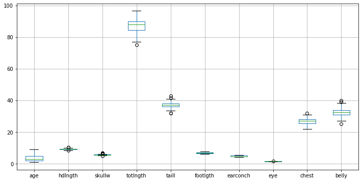

```python
possum_df[col_list[3:]].boxplot(figsize=(12, 6))
```

Correlation

```python
corr = possum_df.corr()
```

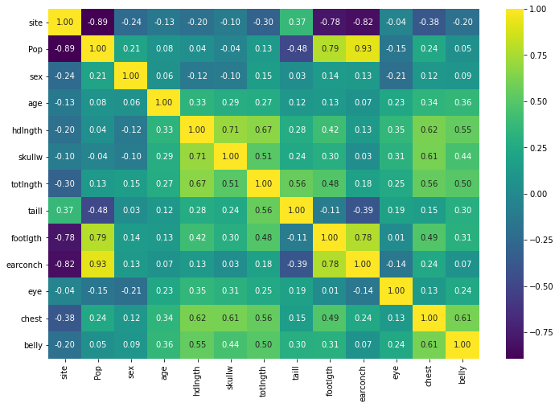

```python
fig, ax = plt.subplots(figsize=(12, 8))
ax = sns.heatmap(corr, annot=True, fmt=".2f", cmap="viridis")
plt.show()
```

#### Predicting Possum Head Length

```python
possum_df = pd.concat([possum_df, site_encoded_df], axis=1)  # adding one-hot-encoded dataframe
possum_df.drop(["site"], axis=1, inplace=True)  # dropping original site column
possum_df.sample(5)
```

|  | Pop | sex | age | hdlngth | skullw | totlngth | taill | footlgth | earconch | eye | chest | belly | site 2 | site 3 | site 4 | site 5 | site 6 | site 7 |
| --- | --- | --- | --- | --- | --- | --- | --- | --- | --- | --- | --- | --- | --- | --- | --- | --- | --- | --- |
| 30 | 1 | 0 | 3 | 9.28 | 5.41 | 93.0 | 37.0 | 6.80 | 5.25 | 1.45 | 27.0 | 31.0 | 0 | 0 | 0 | 0 | 0 | 0 |
| 38 | 1 | 1 | 1 | 8.47 | 5.15 | 75.0 | 34.0 | 6.87 | 5.34 | 1.30 | 25.0 | 25.0 | 1 | 0 | 0 | 0 | 0 | 0 |
| 56 | 0 | 1 | 2 | 9.13 | 5.77 | 88.0 | 39.0 | 6.31 | 4.70 | 1.44 | 26.0 | 30.0 | 0 | 0 | 1 | 0 | 0 | 0 |
| 39 | 1 | 1 | 3 | 9.10 | 5.50 | 84.5 | 36.0 | 7.28 | 5.14 | 1.36 | 27.0 | 30.0 | 1 | 0 | 0 | 0 | 0 | 0 |
| 41 | 1 | 1 | 2 | 9.00 | 5.55 | 81.0 | 32.0 | 7.20 | 4.94 | 1.34 | 29.0 | 31.0 | 1 | 0 | 0 | 0 | 0 | 0 |

```python
features = possum_df.drop(["hdlngth"], axis=1)
target = possum_df["hdlngth"]
```

```python
features.columns
```

```
Index(['Pop', 'sex', 'age', 'skullw', 'totlngth', 'taill', 'footlgth',
       'earconch', 'eye', 'chest', 'belly', 'site 2', 'site 3', 'site 4',
       'site 5', 'site 6', 'site 7'],
      dtype='object')
```

```python
x_train, x_test, y_train, y_test = train_test_split(features, target, test_size=0.2)
```

```python
from sklearn.linear_model import LinearRegression
from sklearn.neighbors import KNeighborsRegressor
from sklearn.ensemble import AdaBoostRegressor
from sklearn.ensemble import BaggingRegressor
from sklearn.ensemble import GradientBoostingRegressor
```

```python
# regressors
reg1 = LinearRegression()
reg2 = KNeighborsRegressor()
reg3 = AdaBoostRegressor()
reg4 = BaggingRegressor()
reg5 = GradientBoostingRegressor()
```

```python
regressors = [reg1, reg2, reg3, reg4, reg5]
```

```python
for reg in regressors:
    reg.fit(x_train, y_train)
```

```python
predictions_df = pd.DataFrame()

predictions_df["Actual Label"] = y_test

for reg in regressors:
    y_pred = reg.predict(x_test)
    predictions_df[reg.__class__.__name__] = np.round(y_pred, 4)

predictions_df.sample(5)
```

|  | Actual Label | LinearRegression | KNeighborsRegressor | AdaBoostRegressor | BaggingRegressor | GradientBoostingRegressor |
| --- | --- | --- | --- | --- | --- | --- |
| 6 | 9.53 | 9.3750 | 9.388 | 9.4700 | 9.498 | 9.7216 |
| 98 | 9.24 | 9.1076 | 9.292 | 9.2536 | 9.274 | 9.2158 |
| 41 | 9.00 | 8.9246 | 9.104 | 9.2380 | 9.277 | 9.0701 |
| 36 | 8.93 | 8.9096 | 9.072 | 9.2380 | 9.130 | 9.0620 |
| 97 | 8.86 | 9.0251 | 8.954 | 9.1644 | 9.213 | 9.0004 |

```python
from sklearn.metrics import mean_squared_error
```

```python
for reg in regressors:
    y_pred = reg.predict(x_test)
    mse = mean_squared_error(y_test, y_pred)
    print(reg.__class__.__name__, mse)
```

```
LinearRegression 0.039887960600269994
KNeighborsRegressor 0.038964761904761884
AdaBoostRegressor 0.0449025033385532
BaggingRegressor 0.040606000000000024
GradientBoostingRegressor 0.050074321119279
```

```python
# storing regressor and mse in a dictionary
mse_dict = {}

for reg in regressors:
    y_pred = reg.predict(x_test)
    mse = mean_squared_error(y_test, y_pred)
    mse_dict[reg.__class__.__name__] = mse
```

```python
# model with the lowest MSE (aka the best performing model)
print("Best Model: ", min(mse_dict, key=mse_dict.get))
```

```
Best Model:  KNeighborsRegressor
```

Cross Validation

```python
mean_mse_dict = {}

for regressor in regressors:

        scores = cross_val_score(regressor, x_train, y_train, cv=5, scoring='neg_mean_squared_error')

        print(regressor)
        print('cross validation mean: ', np.mean(scores))
        print('cross validation standard deviation: ', np.std(scores))

        mean_mse_dict[regressor.__class__.__name__] = abs(np.mean(scores))
        # by design, cross validation always returns a negative MSE value - the actual MSE is simply
        # the positive version of that value, hence why we are storing the absolute value in our dictionary
```

```
LinearRegression()
cross validation mean:  -0.06257914061822437
cross validation standard deviation:  0.014524406801938651
KNeighborsRegressor()
cross validation mean:  -0.07857650000000006
cross validation standard deviation:  0.03255654663927062
AdaBoostRegressor()
cross validation mean:  -0.048820353937871735
cross validation standard deviation:  0.01642894641973011
BaggingRegressor()
cross validation mean:  -0.05697034999999999
cross validation standard deviation:  0.03279301054318304
GradientBoostingRegressor()
cross validation mean:  -0.05506144199800613
cross validation standard deviation:  0.0310394625788355
```

```python
# model with the lowest MSE mean (aka the best performing model)
print("Best Model: ", min(mean_mse_dict, key=mean_mse_dict.get))
```

```
Best Model:  AdaBoostRegressor
```

#### Tweaking our Models

Let's take a closer look at each of our models and try tweaking them to see if we get any better results.

1. Linear Regression

```python
# parameter names and default values for reg1
reg1.get_params()
```

```
{'copy_X': True, 'fit_intercept': True, 'n_jobs': None, 'normalize': False}
```

The linear regression estimator doesn’t provide us with much opportunity to tweak our model - it might be more interesting to take a look at variants like ridge and lasso regression for our hyperparameter tuning instead.

```python
from sklearn import linear_model
```

```python
ridge = linear_model.Ridge()
lasso = linear_model.Lasso()
```

```python
lin_reg_mean_mse_dict = {}

for lin_reg in [ridge, lasso]:

    scores = cross_val_score(regressor, x_train, y_train, cv=10, scoring='neg_mean_squared_error')
    lin_reg_mean_mse_dict[lin_reg.__class__.__name__] = abs(np.mean(scores))

lin_reg_mean_mse_dict
```

```
{'Ridge': 0.06210388101685651, 'Lasso': 0.06216110903154397}
```

a) Optimising Ridge Regression

```python
ridge.get_params()
```

```
{'alpha': 1.0,
 'copy_X': True,
 'fit_intercept': True,
 'max_iter': None,
 'normalize': False,
 'random_state': None,
 'solver': 'auto',
 'tol': 0.001}
```

Grid Search

```python
from sklearn.model_selection import GridSearchCV
```

```python
# find optimal parameters for ridge estimator with grid search

alpha = [0.001, 0.01, 0.1, 1, 10, 100, 1000]
solver = ['auto', 'svd', 'cholesky', 'lsqr', 'sparse_cg', 'sag', 'saga', 'lbfgs']

param_grid = dict(alpha=alpha,
                  solver=solver)

grid = GridSearchCV(estimator=ridge, param_grid=param_grid, scoring='neg_mean_squared_error', verbose=1, n_jobs=-1)

grid_result = grid.fit(x_train, y_train)

print('Best Score: ', grid_result.best_score_)
print('Best Params: ', grid_result.best_params_)
```

```
Fitting 5 folds for each of 56 candidates, totalling 280 fits
```

```
[Parallel(n_jobs=-1)]: Using backend LokyBackend with 8 concurrent workers.
[Parallel(n_jobs=-1)]: Done  34 tasks      | elapsed:    3.9s
```

```
Best Score:  -0.051376807168441396
Best Params:  {'alpha': 10, 'solver': 'lsqr'}
```

```
[Parallel(n_jobs=-1)]: Done 280 out of 280 | elapsed:    4.4s finished
```

b) Optimising Lasso Regression

```python
lasso.get_params()
```

```
{'alpha': 1.0,
 'copy_X': True,
 'fit_intercept': True,
 'max_iter': 1000,
 'normalize': False,
 'positive': False,
 'precompute': False,
 'random_state': None,
 'selection': 'cyclic',
 'tol': 0.0001,
 'warm_start': False}
```

Grid Search

```python
# find optimal parameters for lasso estimator with grid search

alpha = [0.001, 0.01, 0.1, 1, 10, 100, 1000]
max_iter = [100, 500, 1000, 2000, 5000]
tol = [0.00001, 0.0001, 0.001]
selection = ['cyclic', 'random']

param_grid = dict(alpha=alpha,
                  max_iter=max_iter,
                  tol=tol,
                  selection=selection)

grid = GridSearchCV(estimator=lasso, param_grid=param_grid, scoring='neg_mean_squared_error', verbose=1, n_jobs=-1)

grid_result = grid.fit(x_train, y_train)

print('Best Score: ', grid_result.best_score_)
print('Best Params: ', grid_result.best_params_)
```

```
[Parallel(n_jobs=-1)]: Using backend LokyBackend with 8 concurrent workers.
```

```
Fitting 5 folds for each of 210 candidates, totalling 1050 fits
```

```
[Parallel(n_jobs=-1)]: Done  56 tasks      | elapsed:    0.2s
```

```
Best Score:  -0.053511830707731245
Best Params:  {'alpha': 0.01, 'max_iter': 100, 'selection': 'random', 'tol': 0.001}
```

```
[Parallel(n_jobs=-1)]: Done 1050 out of 1050 | elapsed:    1.9s finished
```

1. K-Nearest Neighbours

```python
reg2.get_params()
```

```
{'algorithm': 'auto',
 'leaf_size': 30,
 'metric': 'minkowski',
 'metric_params': None,
 'n_jobs': None,
 'n_neighbors': 5,
 'p': 2,
 'weights': 'uniform'}
```

Let's try different values for `n_neighbors` and evaluate the model performance to find the k value that results in the lowest error.

```python
k_values = [x for x in range(1, 21)]

mse_values = {}

for i in k_values:
    knn = KNeighborsRegressor(n_neighbors=i)
    knn.fit(x_train, y_train)
    predictions = knn.predict(x_test)
    mse = mean_squared_error(y_test, predictions)
    mse_values[i] = mse

mse_values
```

```
{1: 0.0979809523809525,
 2: 0.06244166666666667,
 3: 0.04112962962962961,
 4: 0.042144940476190475,
 5: 0.038964761904761884,
 6: 0.03924312169312154,
 7: 0.03574732750242958,
 8: 0.03567247023809517,
 9: 0.030745502645502607,
 10: 0.027214523809523775,
 11: 0.03225316804407711,
 12: 0.03015664682539689,
 13: 0.030953536207382445,
 14: 0.03160624392614192,
 15: 0.0300720634920635,
 16: 0.029855245535714264,
 17: 0.028716625473718834,
 18: 0.028450338036449113,
 19: 0.02905457063711912,
 20: 0.02960523809523809}
```

```python
optimal_k = min(mse_values, key=mse_values.get)
```

```python
print("The optimal k value is", optimal_k, ", since this value resulted in the lowest MSE.")
```

```
The optimal k value is 10 , since this value resulted in the lowest MSE.
```

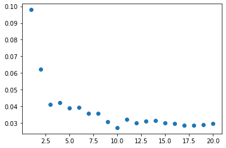

```python
# scatter plot
plt.scatter(x=k_values, y=mse_values.values())
plt.show()
```

1. AdaBoost

```python
reg3.get_params()
```

```
{'base_estimator': None,
 'learning_rate': 1.0,
 'loss': 'linear',
 'n_estimators': 50,
 'random_state': None}
```

Instead of a grid search, let's perform a randomised search where random combinations of the hyperparameters are used to find the best solution for our model. Not all parameter values will be tried out - only a fixed number of parameter settings (given by `n_iter`) is sampled from the specified distributions.

```python
from sklearn.model_selection import RandomizedSearchCV
```

```python
learning_rate = [0.001, 0.01, 0.1, 0.3, 0.5, 0.7, 1.0]
loss = ['linear', 'square', 'exponential']
n_estimators = [20, 50, 100, 200, 400]

param_distributions = dict(learning_rate=learning_rate,
                           loss=loss,
                           n_estimators=n_estimators)

random = RandomizedSearchCV(estimator=reg3, param_distributions=param_distributions, n_iter=25,
                            scoring='neg_mean_squared_error', verbose=1, n_jobs=-1)

random_result = random.fit(x_train, y_train)

print('Best Score: ', random_result.best_score_)
print('Best Params: ', random_result.best_params_)
```

```
Fitting 5 folds for each of 25 candidates, totalling 125 fits
```

```
[Parallel(n_jobs=-1)]: Using backend LokyBackend with 8 concurrent workers.
[Parallel(n_jobs=-1)]: Done  34 tasks      | elapsed:    4.0s
```

```
Best Score:  -0.043850010153624344
Best Params:  {'n_estimators': 20, 'loss': 'square', 'learning_rate': 0.001}
```

```
[Parallel(n_jobs=-1)]: Done 125 out of 125 | elapsed:    7.8s finished
```

1. Bagging Regressor

```python
reg4.get_params()
```

```
{'base_estimator': None,
 'bootstrap': True,
 'bootstrap_features': False,
 'max_features': 1.0,
 'max_samples': 1.0,
 'n_estimators': 10,
 'n_jobs': None,
 'oob_score': False,
 'random_state': None,
 'verbose': 0,
 'warm_start': False}
```

Let's try pasting instead of bagging by setting `bootstrap` to `False`. The individual learners will be trained on data sampled without replacement (as opposed to with replacement when using bagging).

```python
pasting_regressor = BaggingRegressor(bootstrap=False)

pasting_regressor.fit(x_train, y_train)
pasting_pred = pasting_regressor.predict(x_test)

mean_squared_error(y_test, pasting_pred)
```

```
0.11438985714285721
```

```python
# dataframe of actual versus predicted values
df = pd.DataFrame({"Actual" : y_test,
                   "Predicted" : pasting_pred})
df.sample(5)
```

|  | Actual | Predicted |
| --- | --- | --- |
| 41 | 9.00 | 9.100 |
| 79 | 9.00 | 8.584 |
| 97 | 8.86 | 8.896 |
| 6 | 9.53 | 10.166 |
| 43 | 9.01 | 9.800 |

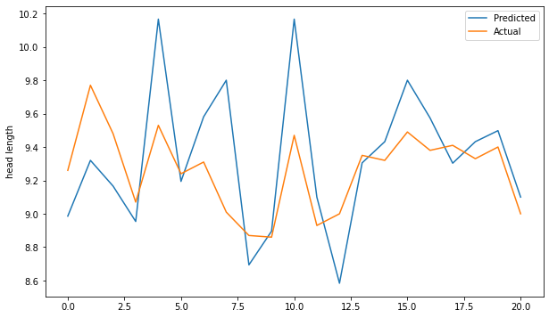

```python
# visual representation of the regression results: line plot of actual versus predicted values
plt.figure(figsize=(10, 6))

plt.plot(pasting_pred, label="Predicted")
plt.plot(y_test.values, label="Actual")

plt.ylabel("head length", fontsize=10)

plt.legend()
plt.show()
```

1. Gradient Boosting Regressor

```python
reg5.get_params()
```

```
{'alpha': 0.9,
 'ccp_alpha': 0.0,
 'criterion': 'friedman_mse',
 'init': None,
 'learning_rate': 0.1,
 'loss': 'ls',
 'max_depth': 3,
 'max_features': None,
 'max_leaf_nodes': None,
 'min_impurity_decrease': 0.0,
 'min_impurity_split': None,
 'min_samples_leaf': 1,
 'min_samples_split': 2,
 'min_weight_fraction_leaf': 0.0,
 'n_estimators': 100,
 'n_iter_no_change': None,
 'presort': 'deprecated',
 'random_state': None,
 'subsample': 1.0,
 'tol': 0.0001,
 'validation_fraction': 0.1,
 'verbose': 0,
 'warm_start': False}
```

All tree-based methods allow us to get feature importances which are scores representing how much each feature contributes to a prediction.

```python
feature_importance_series = pd.Series(reg5.feature_importances_, index=features.columns).sort_values(ascending=False)
round(feature_importance_series, 4)
```

```
skullw      0.5931
totlngth    0.1369
age         0.0761
eye         0.0548
footlgth    0.0484
earconch    0.0282
belly       0.0189
taill       0.0160
site 5      0.0080
site 6      0.0071
chest       0.0047
sex         0.0039
site 7      0.0034
Pop         0.0004
site 3      0.0001
site 2      0.0000
site 4      0.0000
dtype: float64
```

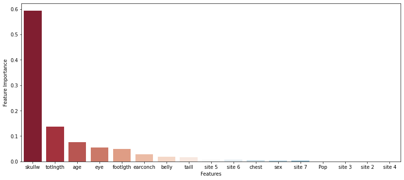

```python
fig, ax = plt.subplots(figsize=(14, 6))
sns.barplot(x = feature_importance_series.index, y = feature_importance_series, palette = "RdBu")

plt.xlabel('Features')
plt.ylabel('Feature Importance')

plt.show()
```

```python
weak_features = []

for i in range(0, len(feature_importance_series)):
    if feature_importance_series[i] < 0.02:
        weak_features.append(feature_importance_series.index[i])

weak_features
```

```
['belly',
 'taill',
 'site 5',
 'site 6',
 'chest',
 'sex',
 'site 7',
 'Pop',
 'site 3',
 'site 2',
 'site 4']
```

Let's remove features with low importance from `x_train` and `x_test`:

```python
x_train = x_train.drop(weak_features, axis=1)
x_test = x_test.drop(weak_features, axis=1)
```

```python
x_train.sample(3)
```

|  | age | skullw | totlngth | footlgth | earconch | eye |
| --- | --- | --- | --- | --- | --- | --- |
| 74 | 1 | 5.10 | 81.0 | 6.30 | 4.43 | 1.32 |
| 91 | 4 | 5.66 | 88.5 | 6.45 | 4.54 | 1.49 |
| 87 | 3 | 5.96 | 89.0 | 6.55 | 4.80 | 1.50 |

```python
x_test.sample(3)
```

|  | age | skullw | totlngth | footlgth | earconch | eye |
| --- | --- | --- | --- | --- | --- | --- |
| 6 | 2 | 5.82 | 89.5 | 7.15 | 5.20 | 1.42 |
| 85 | 6 | 5.84 | 84.5 | 6.44 | 4.62 | 1.44 |
| 70 | 4 | 5.20 | 83.0 | 6.15 | 4.59 | 1.47 |

Let's train a new gradient boosting regressor on the revised set of features. Additionally, let's set `warm_start` to `True` and incrementally add predictors to our model until it stops improving.

```python
gbr = GradientBoostingRegressor(warm_start=True)
```

```python
min_mse = float("inf")
error_increased = 0

for n_estimators in range(1, 100):
    gbr.n_estimators = n_estimators
    gbr.fit(x_train, y_train)

    y_pred = gbr.predict(x_test)
    mse = mean_squared_error(y_test, y_pred)

    print('Number of Estimators: ', gbr.n_estimators_)
    print('MSE: ', mse)

    # if an added estimator improves the model, the MSE falls
    # if we add 10 estimators in a row that don't improve the MSE, we stop adding estimators
    # the number of estimators minus 10 then gives us the best model: n_estimators - 10

    if mse < min_mse:
        min_mse = mse
        error_increased = 0
    else:
        error_increased += 1
        if error_increased == 10:
            break
```

```
Number of Estimators:  1
MSE:  0.04673909224338252
Number of Estimators:  2
MSE:  0.03921533958191298
Number of Estimators:  3
MSE:  0.03358235790815718
Number of Estimators:  4
MSE:  0.03149214684539261
Number of Estimators:  5
MSE:  0.029845279756365622
Number of Estimators:  6
MSE:  0.030603498321939294
Number of Estimators:  7
MSE:  0.030219110431882343
Number of Estimators:  8
MSE:  0.02936751133845338
Number of Estimators:  9
MSE:  0.03009907224847695
Number of Estimators:  10
MSE:  0.03001749344740216
Number of Estimators:  11
MSE:  0.029414588891684763
Number of Estimators:  12
MSE:  0.030291762667656257
Number of Estimators:  13
MSE:  0.030902098962971733
Number of Estimators:  14
MSE:  0.030706214825718246
Number of Estimators:  15
MSE:  0.031487419479089014
Number of Estimators:  16
MSE:  0.03216150113952388
Number of Estimators:  17
MSE:  0.03237114956453798
Number of Estimators:  18
MSE:  0.03293666083688125
```

```python
# best model
optimal_n_estimators = n_estimators - 10
print("The optimal number of estimators is", optimal_n_estimators,
      ", since", optimal_n_estimators, "estimators resulted in the lowest MSE.")
```

```
The optimal number of estimators is 8 , since 8 estimators resulted in the lowest MSE.
```